# Practical Machine Learning Project - Predict Weightlifting Fashion

Michael Lioznov

# **Synopsis**

Class A - correctly per specification.

Class B - throwing the elbows to the front.

Class C - lifting the dumbbell only halfway.

Class E - throwing the hips to the front.

More information is available here: http://groupware.les.inf.puc-rio.br/har#weight_lifting_exercises

# **Data Load and Preparation**

Load required packages

```r
# load the required packages
suppressMessages(library(caret));
suppressMessages(library(rattle));
```

```r
suppressMessages(library(rpart));
suppressMessages(library(rpart.plot))
suppressMessages(library(randomForest));
```

Load training and testing data

```r
# load training and testing data
setwd("C:/Users/egdbb48/PracticalMachineLearning/CourseProject")
download.file(url="https://d396qusza40orc.cloudfront.net/predmachlearn/pml-training.csv",destfile="TrainingData.csv")
download.file(url="https://d396qusza40orc.cloudfront.net/predmachlearn/pml-testing.csv",destfile="TestingData.csv")
testing <- read.csv("TestingData.csv", na.strings = c("NA", "" ,"#DIV/0!"), header = TRUE)
training <- read.csv("TrainingData.csv", na.strings = c("NA", "", "#DIV/0!"), header = TRUE)
```

Exploration of the training and testing sets shows a lot of undefined variables that cannot and should not be used as predictors; also the first 7 variables (X, user_name, raw_timestamp_part_1, raw_timestamp_part_2, cvtd_timestamp, new_window, num_window) obviously cannot correllate with the weightlifting mannors demonstrated by participants.

Cleansing datasets from nonsensical fields:

```r
# Clean test set first - to limit useful predictors:
testClean <- testing[,colSums(is.na(testing)) == 0 ][, -c(1:7)] # & !(colnames(testing) %in% c("problem_id"))
# Find which predictors in the training set should be chosen for modeling mannor of weightlifting (classe)
ColNames <- names(testClean[, !(colnames(testClean) %in% c("problem_id"))])
# Subset the training set
trainClean <- training[ ,c(ColNames,"classe")] # tail(trainClean)
#names(trainClean)
```

# **Data partitioning**

To tune and compare possible models before using them on the testing (testClean) data set the training set was split into the training (Train) and validation (Validate) data sets

```r
set.seed(4321)
PartitionFunc <- createDataPartition(y=trainClean$classe, p=3/4, list=FALSE)
Train <- trainClean[PartitionFunc, ]
Validate <- trainClean[-PartitionFunc, ]
```

# **Compare Prediction Algorithms**

Random Forests (rf) and Classification Trees (rpart) were compared for accuracy.

## **Classification Trees**

For Classification Trees the 20 - fold cross validation was used:

```r
contr <- trainControl(method = "cv", number = 20)
Modelrpart <- train(classe ~ ., data = Train, method = "rpart",trControl = contr)
print(Modelrpart, digits = 4)
```

```
## CART
##
## 14718 samples
##    52 predictor
##     5 classes: 'A', 'B', 'C', 'D', 'E'
##
## No pre-processing
## Resampling: Cross-Validated (20 fold)
## Summary of sample sizes: 13981, 13981, 13983, 13982, 13982, 13983, ...
## Resampling results across tuning parameters:
##
##   cp       Accuracy  Kappa
##   0.03503  0.5032    0.35086
##   0.06038  0.4262    0.22666
##   0.11488  0.3225    0.05824
##
## Accuracy was used to select the optimal model using  the largest value.
## The final value used for the model was cp = 0.03503.
```

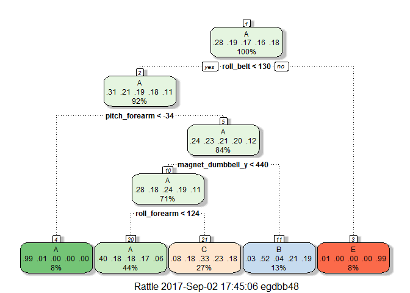

```r
fancyRpartPlot(Modelrpart$finalModel)
```

```r
# Run prediction and show results on Validation set
PredictOnValidateRPART <- predict(Modelrpart, Validate)
confusionMatrix(Validate$classe, PredictOnValidateRPART)
```

```
## Confusion Matrix and Statistics
##
##           Reference
## Prediction    A    B    C    D    E
##          A 1272   19  102    0    2
##          B  402  312  235    0    0
##          C  390   37  428    0    0
##          D  327  166  311    0    0
##          E  119  125  248    0  409
##
## Overall Statistics
##
##                Accuracy : 0.4937
##                  95% CI : (0.4796, 0.5078)
##     No Information Rate : 0.5118
##     P-Value [Acc > NIR] : 0.9947
##
##                   Kappa : 0.3389
##  Mcnemar's Test P-Value : NA
##
## Statistics by Class:
##
##                      Class: A Class: B Class: C Class: D Class: E
## Sensitivity            0.5068  0.47344  0.32326       NA  0.99513
## Specificity            0.9486  0.84994  0.88073   0.8361  0.89050
## Pos Pred Value         0.9118  0.32877  0.50058       NA  0.45394
## Neg Pred Value         0.6472  0.91226  0.77871       NA  0.99950
## Prevalence             0.5118  0.13438  0.26998   0.0000  0.08381
## Detection Rate         0.2594  0.06362  0.08728   0.0000  0.08340
## Detection Prevalence   0.2845  0.19352  0.17435   0.1639  0.18373
## Balanced Accuracy      0.7277  0.66169  0.60199       NA  0.94282
```

The prediction attempt on the Validation set shows unsatisfactory accuracy of 0.4936786 and out-of-sample error rate of 0.5063214

## **Random Forests**

```r
Modelrf <- train(classe ~ .,data=Train,method='rf',ntree=100)
print(Modelrf, digits = 4)
```

```
## Random Forest
##
## 14718 samples
##    52 predictor
##     5 classes: 'A', 'B', 'C', 'D', 'E'
##
## No pre-processing
## Resampling: Bootstrapped (25 reps)
## Summary of sample sizes: 14718, 14718, 14718, 14718, 14718, 14718, ...
## Resampling results across tuning parameters:
##
##   mtry  Accuracy  Kappa
##    2    0.9887    0.9857
##   27    0.9881    0.9850
##   52    0.9791    0.9735
##
## Accuracy was used to select the optimal model using  the largest value.
## The final value used for the model was mtry = 2.
```

The following prediction attempt on the Validation set shows great accuracy:

```r
# Run prediction and show results on Validation set
PredictOnValidateRf <- predict(Modelrf, Validate)
confusionMatrix(Validate$classe, PredictOnValidateRf)
```

```
## Confusion Matrix and Statistics
##
##           Reference
## Prediction    A    B    C    D    E
##          A 1395    0    0    0    0
##          B    9  934    6    0    0
##          C    0   14  840    1    0
##          D    0    0   12  791    1
##          E    0    0    0    3  898
##
## Overall Statistics
##
##                Accuracy : 0.9906
##                  95% CI : (0.9875, 0.9931)
##     No Information Rate : 0.2863
##     P-Value [Acc > NIR] : < 2.2e-16
##
##                   Kappa : 0.9881
##  Mcnemar's Test P-Value : NA
##
## Statistics by Class:
##
##                      Class: A Class: B Class: C Class: D Class: E
## Sensitivity            0.9936   0.9852   0.9790   0.9950   0.9989
## Specificity            1.0000   0.9962   0.9963   0.9968   0.9993
## Pos Pred Value         1.0000   0.9842   0.9825   0.9838   0.9967
## Neg Pred Value         0.9974   0.9965   0.9956   0.9990   0.9998
## Prevalence             0.2863   0.1933   0.1750   0.1621   0.1833
## Detection Rate         0.2845   0.1905   0.1713   0.1613   0.1831
## Detection Prevalence   0.2845   0.1935   0.1743   0.1639   0.1837
## Balanced Accuracy      0.9968   0.9907   0.9877   0.9959   0.9991
```

# **Conclusion**

Prediction accuracy of 0.9906199 is achieved by using RandomForests algorithm. The out-of-sample error rate for the Random Forests algorithm is 0.0093801. Although many predictors seem highly correlated, Random Forests algorithm chooses a subset of predictors at each split. This leads to high accuracy.

```r
# TestPrediction <- predict(Modelrf, newdata=testClean)
# TestPredictionResults <- data.frame(problem_id=testClean$problem_id,predicted=TestPrediction)
# print(TestPredictionResults)
```